# Bayesian GLMM Part5

Author

Murray Logan

Published

09/09/2025

# 1 Preparations

Load the necessary libraries

```r
library(tidyverse) # for data wrangling
library(car) # for regression diagnostics
library(broom) # for tidy output
library(ggfortify) # for model diagnostics
library(knitr) # for kable
library(emmeans) # for estimating marginal means
library(MASS) # for glm.nb
library(brms)
library(broom.mixed)
library(tidybayes)
library(bayesplot)
library(standist) # for visualizing distributions
library(rstanarm)
library(cmdstanr) # for cmdstan
library(ggeffects)
library(rstan)
library(DHARMa)
library(ggridges)
library(easystats) # framework for stats, modelling and visualisation
library(patchwork)
library(modelsummary)
library(geoR)
source("helperFunctions.R")
```

# 2 Scenario

Some ornithologists were interested in the degree of sibling negotiations in owl chicks. Specifically, they wanted to explore how sibling negotiations were affected by feeding satiety and the sex of the parent returning to the nest. The ornithologists had accessed to a number of owl nests and were able to count (via recording equipment) the number of sibling negotiations (calls) that the owl chicks made when the parent returned to the nest.

We could hypothesise that the chicks might call more if they were hungry. As part of the investigation, the researchers were able to provided supplementary food. As such, they were able to manipulate the conditions such that sometimes the chicks in a nest would be considered deprived of supplementary food and at other times they were satiated.

As a parent returned, the researchers recorded the number of sibling negotiations (calls) along with the sex of the parent. Since the number of calls is likely to be a function of the number of chicks (the more chicks the more calls), the researchers also counted the number of siblings in the brood.

Each nest was measured on multiple occasions. Hence, we must include the nest as a random effect to account for the lack of independence between observations on the same set of siblings.

# 3 Read in the data

```r
owls <- read_csv("../data/owls.csv", trim_ws = TRUE)
```

**glimpse**

```r
glimpse(owls)
```

```
Rows: 599
Columns: 7
$ Nest               <chr> "AutavauxTV", "AutavauxTV", "AutavauxTV", "Autavaux…
$ FoodTreatment      <chr> "Deprived", "Satiated", "Deprived", "Deprived", "De…
$ SexParent          <chr> "Male", "Male", "Male", "Male", "Male", "Male", "Ma…
$ ArrivalTime        <dbl> 22.25, 22.38, 22.53, 22.56, 22.61, 22.65, 22.76, 22…
$ SiblingNegotiation <dbl> 4, 0, 2, 2, 2, 2, 18, 4, 18, 0, 0, 3, 0, 3, 3, 6, 0…
$ BroodSize          <dbl> 5, 5, 5, 5, 5, 5, 5, 5, 5, 5, 5, 5, 5, 5, 5, 5, 5, …
$ NegPerChick        <dbl> 0.8, 0.0, 0.4, 0.4, 0.4, 0.4, 3.6, 0.8, 3.6, 0.0, 0…
```

**head**

```r
## Explore the first 6 rows of the data
head(owls)
```

```
# A tibble: 6 × 7
  Nest       FoodTreatment SexParent ArrivalTime SiblingNegotiation BroodSize
  <chr>      <chr>         <chr>           <dbl>              <dbl>     <dbl>
1 AutavauxTV Deprived      Male             22.2                  4         5
2 AutavauxTV Satiated      Male             22.4                  0         5
3 AutavauxTV Deprived      Male             22.5                  2         5
4 AutavauxTV Deprived      Male             22.6                  2         5
5 AutavauxTV Deprived      Male             22.6                  2         5
6 AutavauxTV Deprived      Male             22.6                  2         5
# ℹ 1 more variable: NegPerChick <dbl>
```

**str**

```r
str(owls)
```

```
spc_tbl_ [599 × 7] (S3: spec_tbl_df/tbl_df/tbl/data.frame)
 $ Nest              : chr [1:599] "AutavauxTV" "AutavauxTV" "AutavauxTV" "AutavauxTV" ...
 $ FoodTreatment     : chr [1:599] "Deprived" "Satiated" "Deprived" "Deprived" ...
 $ SexParent         : chr [1:599] "Male" "Male" "Male" "Male" ...
 $ ArrivalTime       : num [1:599] 22.2 22.4 22.5 22.6 22.6 ...
 $ SiblingNegotiation: num [1:599] 4 0 2 2 2 2 18 4 18 0 ...
 $ BroodSize         : num [1:599] 5 5 5 5 5 5 5 5 5 5 ...
 $ NegPerChick       : num [1:599] 0.8 0 0.4 0.4 0.4 0.4 3.6 0.8 3.6 0 ...
 - attr(*, "spec")=
  .. cols(
  ..   Nest = col_character(),
  ..   FoodTreatment = col_character(),
  ..   SexParent = col_character(),
  ..   ArrivalTime = col_double(),
  ..   SiblingNegotiation = col_double(),
  ..   BroodSize = col_double(),
  ..   NegPerChick = col_double()
  .. )
 - attr(*, "problems")=<externalptr>
```

**Easystats (datawizard)**

```r
owls |> datawizard::data_codebook()
```

```
owls (599 rows and 7 variables, 7 shown)

ID | Name               | Type      | Missings |          Values |           N
---+--------------------+-----------+----------+-----------------+------------
1  | Nest               | character | 0 (0.0%) |      AutavauxTV |  28 ( 4.7%)
   |                    |           |          |          Bochet |  23 ( 3.8%)
   |                    |           |          |     Champmartin |  30 ( 5.0%)
   |                    |           |          |         ChEsard |  20 ( 3.3%)
   |                    |           |          |        Chevroux |  10 ( 1.7%)
   |                    |           |          | CorcellesFavres |  12 ( 2.0%)
   |                    |           |          |        Etrabloz |  34 ( 5.7%)
   |                    |           |          |           Forel |   4 ( 0.7%)
   |                    |           |          |          Franex |  26 ( 4.3%)
   |                    |           |          |            GDLV |  10 ( 1.7%)
   |                    |           |          |           (...) |
---+--------------------+-----------+----------+-----------------+------------
2  | FoodTreatment      | character | 0 (0.0%) |        Deprived | 320 (53.4%)
   |                    |           |          |        Satiated | 279 (46.6%)
---+--------------------+-----------+----------+-----------------+------------
3  | SexParent          | character | 0 (0.0%) |          Female | 245 (40.9%)
   |                    |           |          |            Male | 354 (59.1%)
---+--------------------+-----------+----------+-----------------+------------
4  | ArrivalTime        | numeric   | 0 (0.0%) |  [21.71, 29.25] |         599
---+--------------------+-----------+----------+-----------------+------------
5  | SiblingNegotiation | numeric   | 0 (0.0%) |         [0, 32] |         599
---+--------------------+-----------+----------+-----------------+------------
6  | BroodSize          | numeric   | 0 (0.0%) |          [1, 7] |         599
---+--------------------+-----------+----------+-----------------+------------
7  | NegPerChick        | numeric   | 0 (0.0%) |        [0, 8.5] |         599
------------------------------------------------------------------------------
```

**Skim (modelsummary)**

Unique

Missing Pct.

Mean

SD

Min

Median

Max

Histogram

ArrivalTime

317

0

24.8

1.9

21.7

24.4

29.2

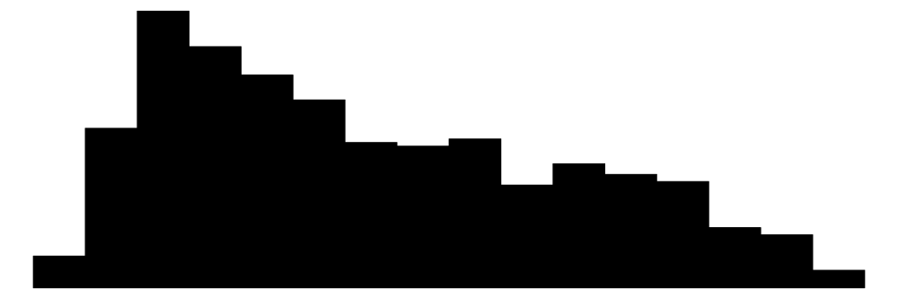

SiblingNegotiation

29

0

6.7

6.7

0.0

5.0

32.0

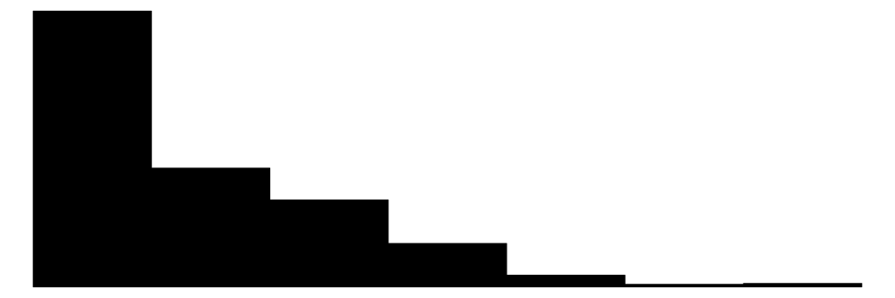

BroodSize

7

0

4.4

1.2

1.0

4.0

7.0

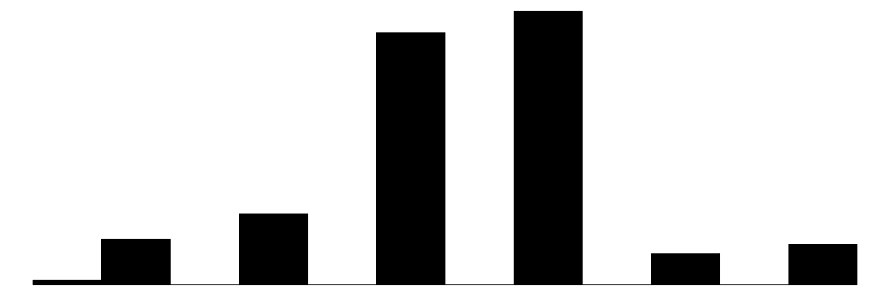

NegPerChick

78

0

1.6

1.6

0.0

1.2

8.5

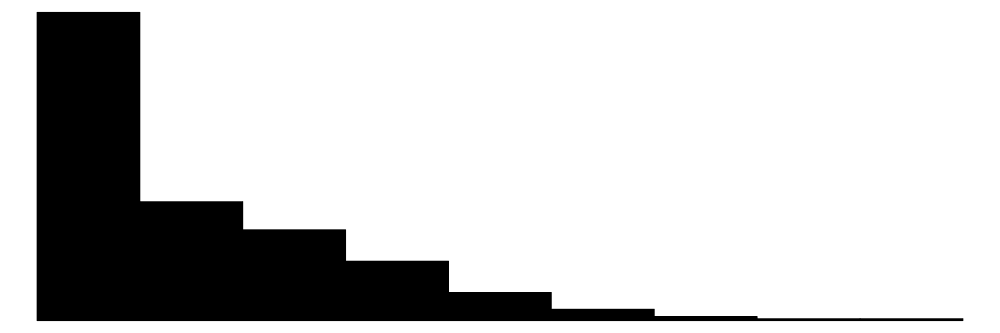

N

%

Nest

AutavauxTV

28

4.7

Bochet

23

3.8

Champmartin

30

5.0

ChEsard

20

3.3

Chevroux

10

1.7

CorcellesFavres

12

2.0

Etrabloz

34

5.7

Forel

4

0.7

Franex

26

4.3

GDLV

10

1.7

Gletterens

15

2.5

Henniez

13

2.2

Jeuss

19

3.2

LesPlanches

17

2.8

Lucens

29

4.8

Lully

17

2.8

Marnand

27

4.5

Montet

41

6.8

Murist

24

4.0

Oleyes

52

8.7

Payerne

25

4.2

Rueyes

17

2.8

Seiry

26

4.3

Sevaz

4

0.7

StAubin

23

3.8

Trey

19

3.2

Yvonnand

34

5.7

FoodTreatment

Deprived

320

53.4

Satiated

279

46.6

SexParent

Female

245

40.9

Male

354

59.1

```r
owls |> modelsummary::datasummary_skim()
```

SexParent

FoodTreatment

Unique

Missing Pct.

Mean

SD

Min

Median

Max

Histogram

ArrivalTime

Male

Deprived

160

0

24.9

2.0

22.0

24.4

29.2

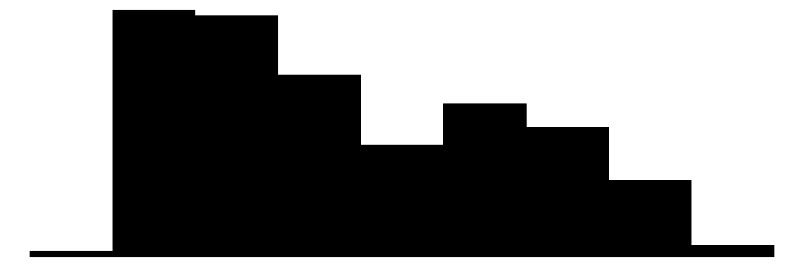

Male

Satiated

128

0

24.7

1.8

21.8

24.5

29.1

[figure not shown]

Female

Satiated

105

0

24.6

1.9

21.7

24.4

29.2

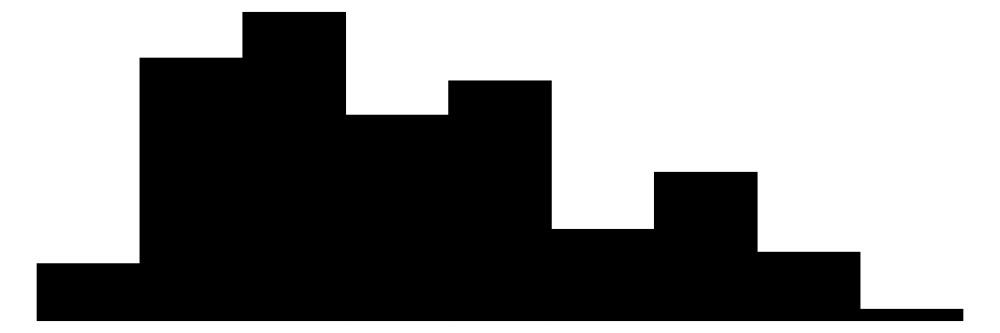

Female

Deprived

107

0

24.8

2.0

22.0

24.2

29.2

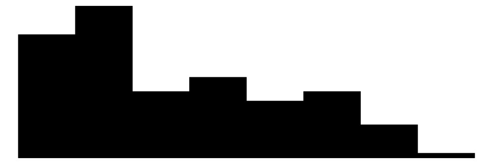

SiblingNegotiation

Male

Deprived

25

0

8.7

6.5

0.0

7.0

31.0

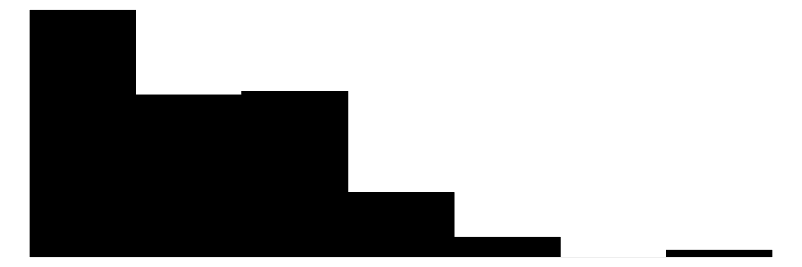

Male

Satiated

23

0

5.3

6.6

0.0

3.0

32.0

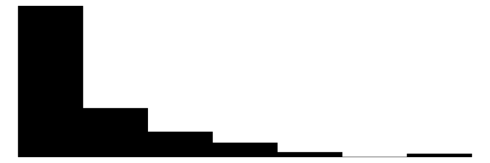

Female

Satiated

22

0

4.8

6.5

0.0

1.5

26.0

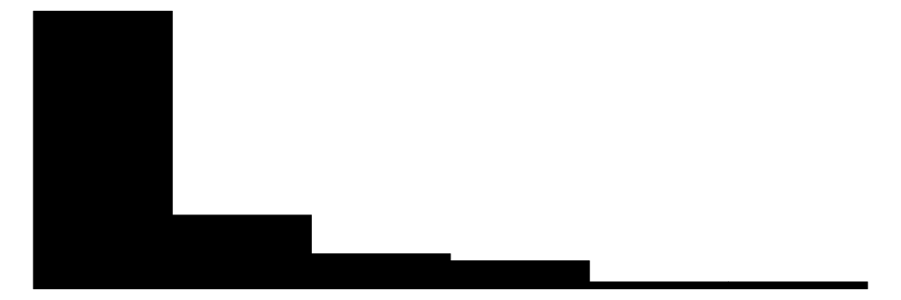

Female

Deprived

21

0

7.3

6.3

0.0

6.0

28.0

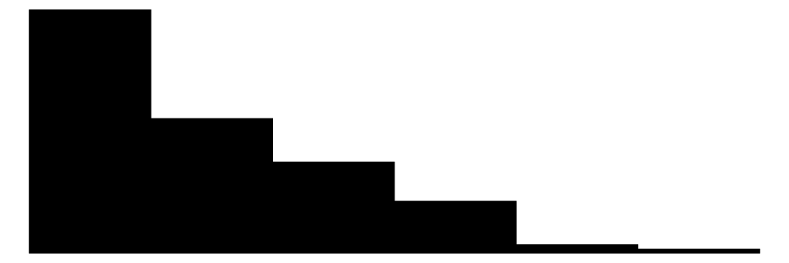

BroodSize

Male

Deprived

7

0

4.5

1.1

1.0

4.0

7.0

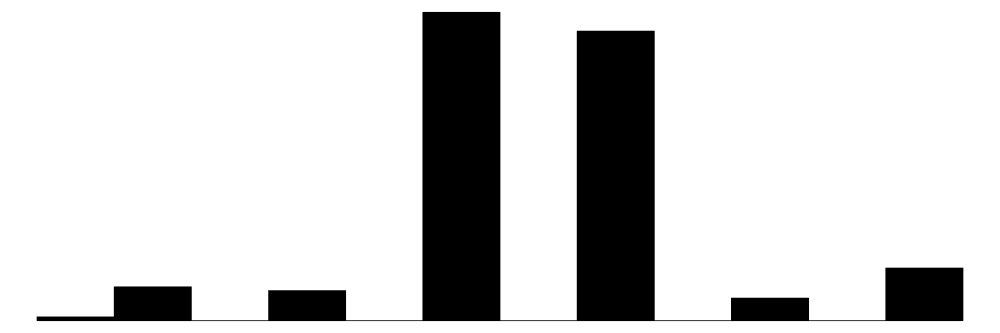

Male

Satiated

7

0

4.4

1.1

1.0

5.0

7.0

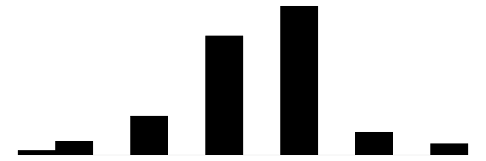

Female

Satiated

7

0

4.5

1.3

1.0

5.0

7.0

[figure not shown]

Female

Deprived

6

0

4.0

1.1

2.0

4.0

7.0

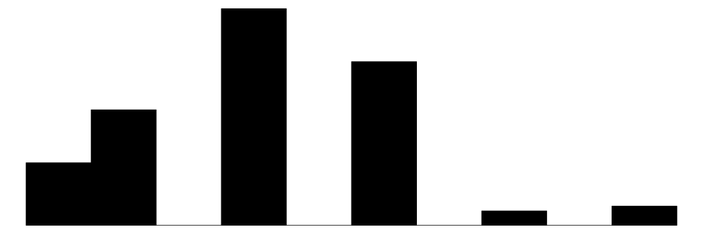

NegPerChick

Male

Deprived

52

0

2.0

1.5

0.0

1.5

8.5

[4 more figures not shown]

N

%

Nest

AutavauxTV

28

4.7

Bochet

23

3.8

Champmartin

30

5.0

ChEsard

20

3.3

Chevroux

10

1.7

CorcellesFavres

12

2.0

Etrabloz

34

5.7

Forel

4

0.7

Franex

26

4.3

GDLV

10

1.7

Gletterens

15

2.5

Henniez

13

2.2

Jeuss

19

3.2

LesPlanches

17

2.8

Lucens

29

4.8

Lully

17

2.8

Marnand

27

4.5

Montet

41

6.8

Murist

24

4.0

Oleyes

52

8.7

Payerne

25

4.2

Rueyes

17

2.8

Seiry

26

4.3

Sevaz

4

0.7

StAubin

23

3.8

Trey

19

3.2

Yvonnand

34

5.7

FoodTreatment

Deprived

320

53.4

Satiated

279

46.6

SexParent

Female

245

40.9

Male

354

59.1

```r
owls |> modelsummary::datasummary_skim(by = c("SexParent", "FoodTreatment"))
```

# 4 Data preparation

Let start by declaring the categorical variables and random effect as factors.

```r
## Amount of Sibling negotiation (vocalizations when parents are absent)
## Foot treatment (deprived or satiated
## Sex of parent
## Arrival time of parent
## Nest as random
## Brood size offset
owls <- owls |> mutate(
  Nest = factor(Nest),
  FoodTreatment = factor(FoodTreatment),
  SexParent = factor(SexParent),
  NCalls = SiblingNegotiation
)
```

# 5 Exploratory data analysis

As the response represents counts (the number of calls), it would make sense to start by considering a Poisson model. We could attempt to model the response as the number of calls divided by the brood size, but this would result in a response that has no natural distribution.

Instead, if we include brood size as an **offset**, it will standardise the effects according to brood size (similar to having divided the response by brood size), yet retain the Poisson nature of the response.

The effects of offsets, unlike regular covariates, are not estimated. Rather they are assumed to be 1 (on the link scale). This means that since Poisson uses a log link, then the offset should be of a logged version of the brood size.

Random intercept/slope model formula:

$$\begin{align}
y_i &\sim{} \mathcal{NB}(\mu_{ij}, \phi)\\
ln\left(\mu_{ij}\right) &=\boldsymbol{\beta} \bf{X_i} + \boldsymbol{\gamma} \bf{Z_i}\\
\beta_0 &\sim{} \mathcal{N}(0.4, 0.7)\\
\beta_1 &\sim{} \mathcal{N}(0, 1)\\
\boldsymbol{\gamma_j} &\sim{} \mathcal{N}(0, \boldsymbol{\Sigma})\\
\boldsymbol{\Sigma} &= \boldsymbol{D}({\sigma_n^2})\boldsymbol{\Omega}\boldsymbol{D}({\sigma_n^2})\\
\boldsymbol{\Omega} &\sim{} LKJ(\zeta)\\
\sigma_n^2 &\sim{} \mathcal{t}(3,0,0.7)\\
\phi &\sim{} \mathcal{\Gamma}(0.01, 0.01)\\
\end{align}$$

where $\boldsymbol{\beta}$ and $\boldsymbol{\gamma}$ are vectors of the fixed and random effects parameters respectively and $\bf{X}$ is the model matrix representing the overall intercept and effects of food treatment, sex of parent, arrival time (and various interactions) on the number of sibling negotiations. Brood size was also incorporated as an offset. $\bf{Z}$ represents a cell means model matrix for the random intercepts associated with individual nests.

**Violin plots**

Perhaps we could start off by exploring the main fixed effects. To mimic the log-link, we will use a log-transformed y axis. Since there may well be zeros (no calls detected), we will use a pseudo log scale). We will also include the raw data (jittered and dodged)

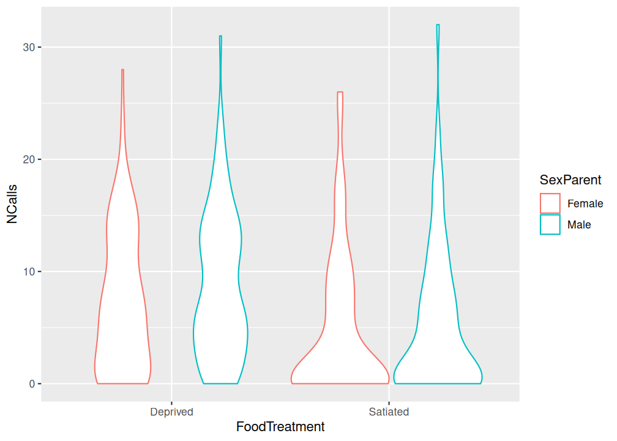

```r
ggplot(data = owls, aes(y = NCalls, x = FoodTreatment, color = SexParent)) +
  geom_violin()
```

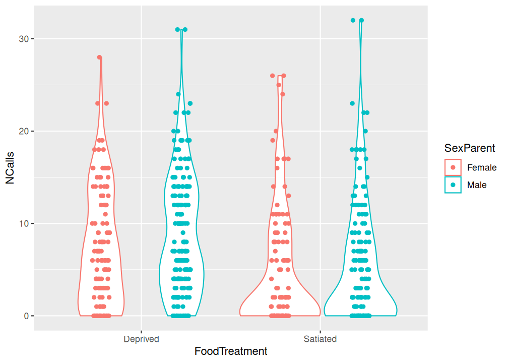

```r
ggplot(data = owls, aes(y = NCalls, x = FoodTreatment, color = SexParent)) +
  geom_violin() +
  geom_point(position = position_jitterdodge(jitter.width = 0.2, dodge.width = 0.9))
```

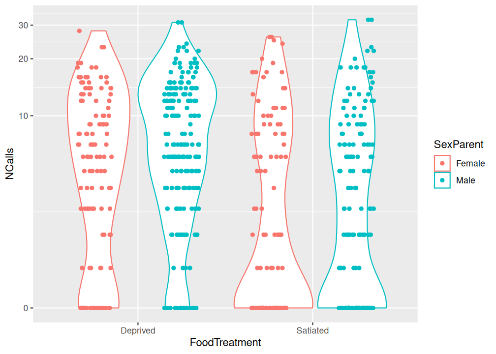

```r
ggplot(data = owls, aes(y = NCalls, x = FoodTreatment, color = SexParent)) +
  geom_violin() +
  geom_point(position = position_jitterdodge(jitter.height = 0, dodge.width = 1)) +
  scale_y_continuous(trans = scales::pseudo_log_trans())
```

**Facetted plots**

Now, a similar plot separated for each nest.

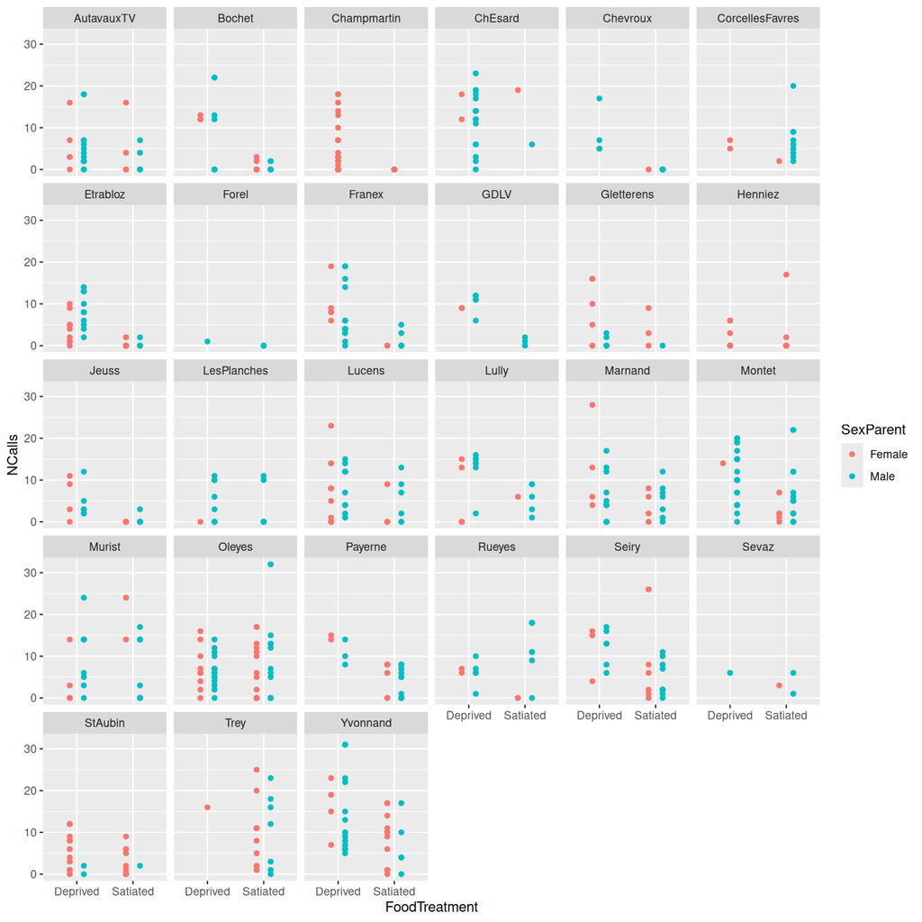

```r
ggplot(data = owls) +
  geom_point(aes(y = NCalls, x = FoodTreatment, color = SexParent), position = position_dodge(0.5)) +
  facet_wrap(~Nest)
```

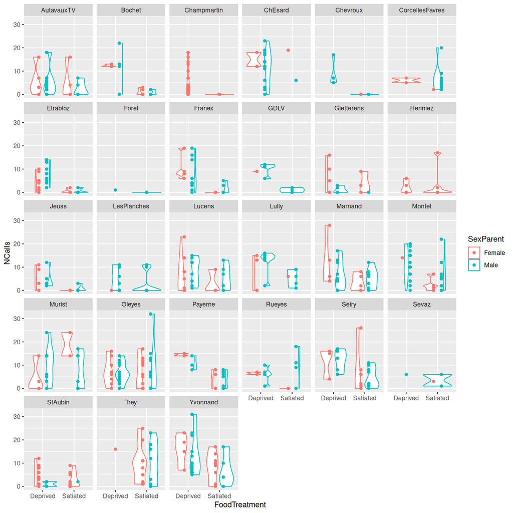

```r
ggplot(data = owls) +
  geom_violin(aes(y = NCalls, x = FoodTreatment, color = SexParent)) +
  geom_point(aes(y = NCalls, x = FoodTreatment, color = SexParent), position = position_dodge(0.5)) +
  facet_wrap(~Nest)
```

**Smoothers**

It might also be worth establishing that there is a linear relationship between the number of calls and brood size. Again, we will mimic the use of the log-link by transforming the axes.

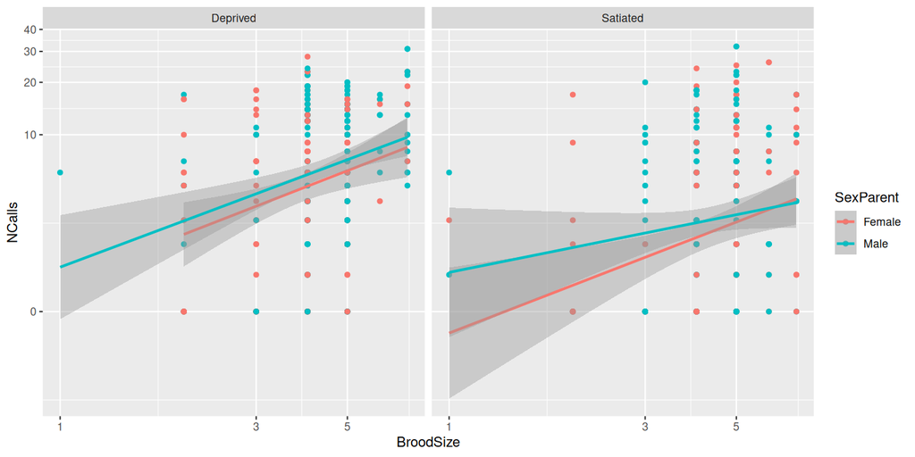

```r
ggplot(data = owls, aes(y = NCalls, x = BroodSize, color = SexParent)) +
  geom_point() +
  geom_smooth(method = "lm") +
  facet_grid(~FoodTreatment) +
  scale_y_continuous(trans = scales::pseudo_log_trans()) +
  scale_x_log10()
```

# 6 Fit the model

This model has the potential to be more complex than most of the models in previous worksheets. Therefore, we will use the current example to illustrate the process of building a model up gradually rather than attempting to fit a more complex model from the start. The benifit of gradually building a model is that it becomes much easier to construct more sensible and appropriate models that perform nicely and meet all the various assumptions.

As we intend to build a number of models, we will nest the MCMC sampling diagnostics and Model validation sections under the Fit the model section since each model will have its own associated diagnostic testing.

Typically, when we are building up models, we start by constructing a model that only contains the hierarchical (random effects) structure.

**rstanarm**

**Using default priors**

In `rstanarm`, the default priors are designed to be weakly informative. They are chosen to provide moderate regularisation (to help prevent over-fitting) and help stabilise the computations.

```r
owls_rstanP <- stan_glmer(
  NCalls ~ FoodTreatment * SexParent +
    offset(log(BroodSize)) + (1 | Nest),
  data = owls,
  family = poisson(link = "log"),
  refresh = 0,
  iter = 5000,
  warmup = 2000,
  thin = 10,
  chains = 3,
  cores = 3
)
```

```r
owls_rstanP |> prior_summary()
```

```
Priors for model 'owls_rstanP'
------
Intercept (after predictors centered)
 ~ normal(location = 0, scale = 2.5)

Coefficients
  Specified prior:
    ~ normal(location = [0,0,0], scale = [2.5,2.5,2.5])
  Adjusted prior:
    ~ normal(location = [0,0,0], scale = [5.01,5.08,5.68])

Covariance
 ~ decov(reg. = 1, conc. = 1, shape = 1, scale = 1)
------
See help('prior_summary.stanreg') for more details
```

This tells us:

- for the intercept (when the family is Gaussian), a normal prior with a mean of 0 and a standard deviation of 2.5 is used. The 2.5 is used for all intercepts. This is then scaled to the scale of the data by multiplying by the standard deviation of the response. When this results in values less than 2.5, it is replaced with 2.5.

```r
2.5 / sd(owls$NCalls)
```

```
[1] 0.3747667
```

```r
model.matrix(~ FoodTreatment * SexParent + offset(log(BroodSize)), data = owls) |>
  apply(2, sd) * 1 / 2.5
```

```
                        (Intercept)               FoodTreatmentSatiated
                          0.0000000                           0.1996977
                      SexParentMale FoodTreatmentSatiated:SexParentMale
                          0.1968252                           0.1760585
```

**Assessing priors**

Lets now run with priors only so that we can explore the range of values they allow in the posteriors.

```r
owls_rstanarmP1 <- update(owls_rstanP, prior_PD = TRUE)
```

[output not shown]

[output not shown]

```
Note: uncertainty of error terms are not taken into account. Consider
  setting `interval` to "prediction". This will call `posterior_predict()`
  instead of `posterior_epred()`.
```

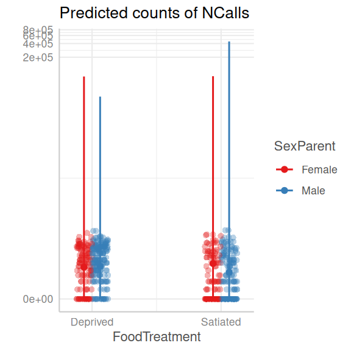

```r
owls_rstanarmP1 |>
  ggpredict(~ FoodTreatment * SexParent) |>
  plot(show_data = TRUE, jitter = c(0.25, 0)) +
  scale_y_continuous("", trans = scales::pseudo_log_trans())
```

**Conclusions:**

- we see that the range of predictions is fairly wide and the predicted means could range from a small value to a relatively large value.

**Defining priors**

The following link provides some guidance about defining priors. [https://github.com/stan-dev/stan/wiki/Prior-Choice-Recommendations]

When defining our own priors, we typically do not want them to be scaled.

If we wanted to define our own priors that were less vague, yet still not likely to bias the outcomes, we could try the following priors (mainly plucked out of thin air):

I will also overlay the raw data for comparison.

```r
owls_rstanarmP2 <- stan_glmer(
  NCalls ~ FoodTreatment * SexParent +
    offset(log(BroodSize)) + (1 | Nest),
  data = owls,
  family = poisson(link = "log"),
  prior_intercept = normal(0, 1.5, autoscale = FALSE),
  prior = normal(0, c(2.2, 2.2, 2.5), autoscale = FALSE),
  prior_aux = exponential(1),
  prior_covariance = decov(1, 1, 1, 1),
  refresh = 0,
  iter = 5000,
  prior_PD = TRUE,
  warmup = 2000,
  thin = 10,
  chains = 3,
  cores = 3
)
```

[output not shown]

```
Note: uncertainty of error terms are not taken into account. Consider
  setting `interval` to "prediction". This will call `posterior_predict()`
  instead of `posterior_epred()`.
```

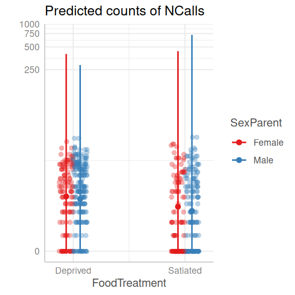

```r
owls_rstanarmP2 |>
  ggpredict(~ FoodTreatment * SexParent) |>
  plot(show_data = TRUE, jitter = c(0.25, 0)) +
  scale_y_continuous("", trans = scales::pseudo_log_trans())
```

Now lets refit, conditioning on the data.

```r
owls_rstanarmP3 <- update(owls_rstanarmP2, prior_PD = FALSE)
```

**Plotting prior and posterior**

```
Drawing from prior...
```

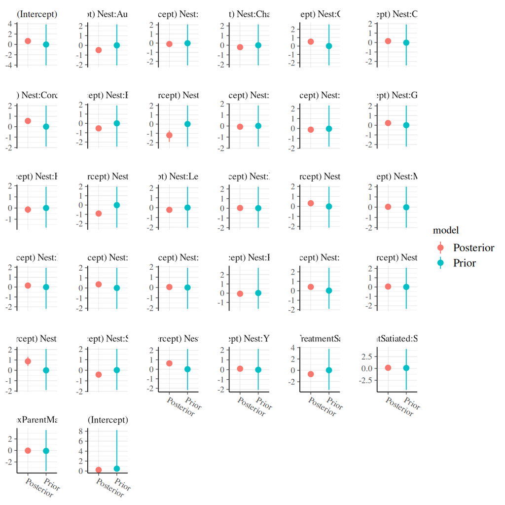

```r
posterior_vs_prior(owls_rstanarmP3,
  color_by = "vs", group_by = TRUE,
  facet_args = list(scales = "free_y")
)
```

**Conclusions:**

- in each case, the prior is substantially wider than the posterior, suggesting that the posterior is not biased towards the prior.

**brms**

**Using default priors**

In `brms`, the default priors are designed to be weakly informative. They are chosen to provide moderate regularisation (to help prevent over fitting) and help stabilise the computations.

Unlike `rstanarm`, `brms` models must be compiled before they start sampling. For most models, the compilation of the stan code takes around 45 seconds.

```r
owls_form <- bf(NCalls ~ FoodTreatment*SexParent +
                    offset(log(BroodSize)) + (1|Nest),
                family=poisson(link='log'))
options(width=150)
owls_form |> get_prior(data = owls)
```

```
                               prior     class                                coef group resp dpar nlpar lb ub       source
                              (flat)         b                                                                      default
                              (flat)         b               FoodTreatmentSatiated                             (vectorized)
                              (flat)         b FoodTreatmentSatiated:SexParentMale                             (vectorized)
                              (flat)         b                       SexParentMale                             (vectorized)
 student_t(3, 0.16097150412244, 2.5) Intercept                                                                      default
                student_t(3, 0, 2.5)        sd                                                            0         default
                student_t(3, 0, 2.5)        sd                                      Nest                  0    (vectorized)
                student_t(3, 0, 2.5)        sd                           Intercept  Nest                  0    (vectorized)
```

```r
options(width=80)
```

**Model 1**

**Fit model**

The following link provides some guidance about defining priors. [https://github.com/stan-dev/stan/wiki/Prior-Choice-Recommendations]

When defining our own priors, we typically do not want them to be scaled.

If we wanted to define our own priors that were less vague, yet still not likely to bias the outcomes, we could try the following priors (mainly plucked out of thin air):

Note, for hierarchical models, the model will tend to want to have a large $sigma$ in order to fit the data better. It is a good idea to **regularise** this tendency by applying a prior that has most mass around zero. Suitable candidates include:

- half-t: as the degrees of freedom approach infinity, this will approach a half-normal
- half-cauchy: this is essentially a half-t with 1 degree of freedom
- exponential

I will also overlay the raw data for comparison.

```r
owls_form <- bf(
  NCalls ~ +
    offset(log(BroodSize)) + (1 | Nest),
  family = poisson(link = "log")
)
options(width = 150)
owls_form |> get_prior(data = owls)
```

```
                               prior     class      coef group resp dpar nlpar lb ub       source
 student_t(3, 0.16097150412244, 2.5) Intercept                                            default
                student_t(3, 0, 2.5)        sd                                  0         default
                student_t(3, 0, 2.5)        sd            Nest                  0    (vectorized)
                student_t(3, 0, 2.5)        sd Intercept  Nest                  0    (vectorized)
```

```r
options(width = 80)
owls |>
  summarise(
    Mean = log(median(NCalls / BroodSize)),
    SD = log(sd(NCalls / BroodSize)),
    MAD = log(mad(NCalls / BroodSize))
  )
```

```
# A tibble: 1 × 3
   Mean    SD   MAD
  <dbl> <dbl> <dbl>
1 0.182 0.479 0.576
```

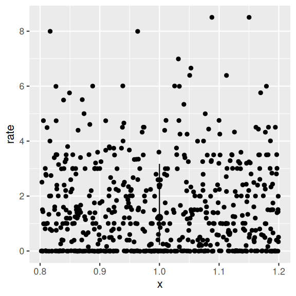

```r
priors <- prior(normal(0.2, 0.6), class = "Intercept") +
  prior(student_t(3, 0, 0.6), class = "sd")
owls_brm1a <- brm(owls_form,
  data = owls,
  prior = priors,
  sample_prior = "only",
  iter = 5000,
  warmup = 2500,
  chains = 3,
  cores = 3,
  thin = 10,
  refresh = 0,
  seed = 123,
  control = list(adapt_delta = 0.99),
  backend = "rstan"
)
owls_brm1a |>
  emmeans(~1, type = "response") |>
  as.data.frame() |>
  ggplot(aes(x = 1, y = rate)) +
  geom_pointrange(aes(ymin = lower.HPD, ymax = upper.HPD)) +
  geom_point(
    data = owls, aes(y = NCalls / BroodSize),
    position = position_jitter(width = 0.2)
  )
```

```r
owls_brm1b <- update(owls_brm1a,
  sample_prior = "yes",
  iter = 5000,
  warmup = 2500,
  control = list(adapt_delta = 0.99, max_treedepth = 20),
  backend = "rstan",
  refresh = 0
)
```

```
The desired updates require recompiling the model
```

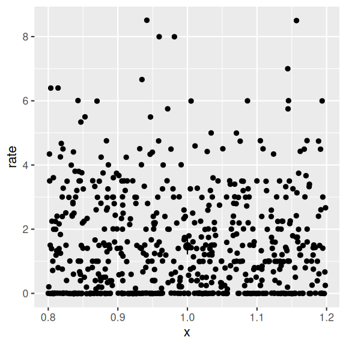

```r
owls_brm1b |>
  emmeans(~1, type = "response") |>
  as.data.frame() |>
  ggplot(aes(x = 1, y = rate)) +
  geom_pointrange(aes(ymin = lower.HPD, ymax = upper.HPD)) +
  geom_point(
    data = owls, aes(y = NCalls / BroodSize),
    position = position_jitter(width = 0.2)
  )
```

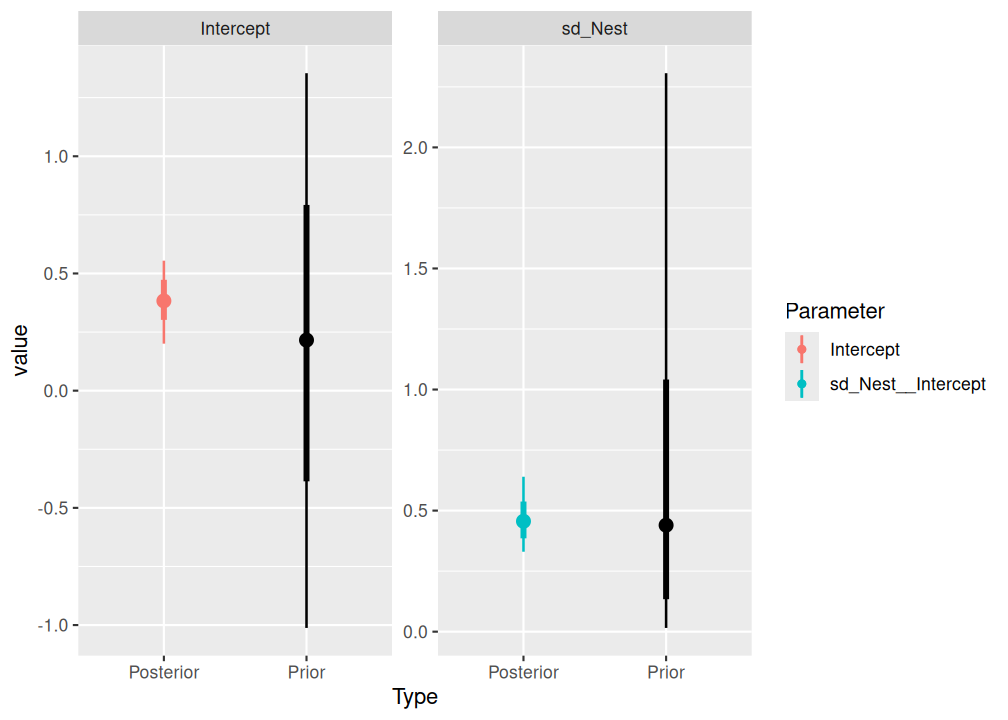

```r
owls_brm1b |> SUYR_prior_and_posterior()
```

```r
owls |>
  group_by(FoodTreatment, SexParent) |>
  summarise(
    Mean = log(median(NCalls / BroodSize)),
    SD = log(sd(NCalls / BroodSize)),
    MAD = log(mad(NCalls / BroodSize))
  )
```

```
# A tibble: 4 × 5
# Groups:   FoodTreatment [2]
  FoodTreatment SexParent   Mean    SD    MAD
  <fct>         <fct>      <dbl> <dbl>  <dbl>
1 Deprived      Female     0.405 0.562  0.656
2 Deprived      Male       0.405 0.416  0.489
3 Satiated      Female    -1.23  0.399 -0.838
4 Satiated      Male      -0.511 0.431 -0.117
```

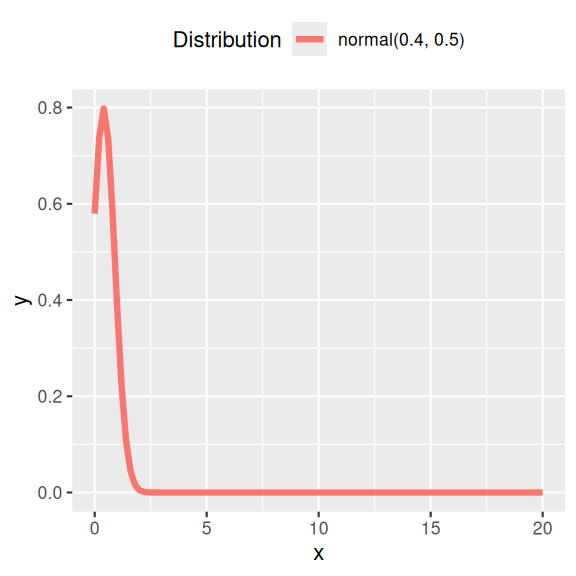

```r
standist::visualize("normal(0.4, 0.5)", xlim = c(0, 20))
```